# PROJECT 7

MBUBA EBERE

2024-02-08

# **TWO WAY ANOVA FOR A LARGE AGRICULTURAL COMPANY ANALYSIS**

### The null and alternative hypotheses.

A = Grass_Species

B = Fertilizer_Type

H0A: The means of levels of factor A are equal (μA1 = μA2)

H0B: The means of levels of factor B are equal (μB1 = μB2 = μB3)

H0AB: The effect of factor A are constant across the levels of factor B

HA: At least one mean is different from the others

### The type of experiment is this

A factorial experiment. Where there are two factors (grass species and fertilizer type) and each factor has multiple levels (2 levels for grass species and 3 levels for fertilizer type)

### The different treatment groups are there

6 treatment groups. (2 levels for Grass Species×3 levels for Fertilizer Type)

### The response variable

number of blades by species.

### Three groups of boxplots

```r
# Loading the dataset
Grass_data <- read.csv(file = file.choose(), header = TRUE)
```

```r
# Converting species and fertilizer to factors (categorical variables)
Grass_data$Species <- as.factor(Grass_data$Species)
Grass_data$Fertilizer <- as.factor(Grass_data$Fertilizer)
```

### number of blades by species

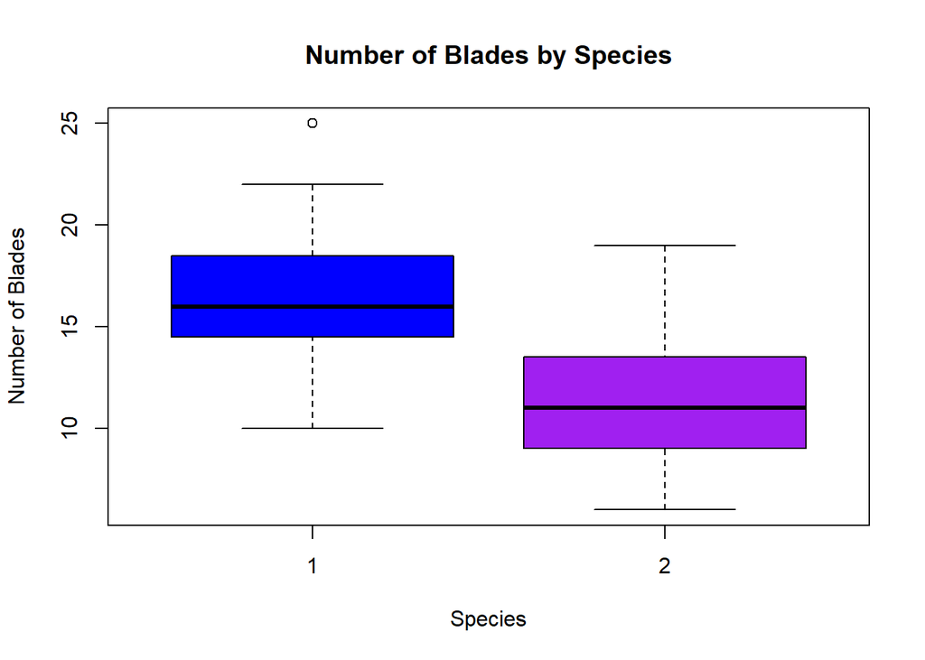

```r
#Create boxplots for each of the factors
boxplot(Blades ~ Species, Grass_data, col = c("blue", "purple"),
        ylab = "Number of Blades", main = "Number of Blades by Species")
```

### Number of blades by fertilizer

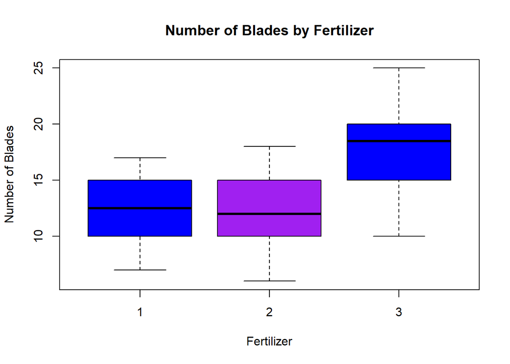

```r
boxplot(Blades ~ Fertilizer, Grass_data, col = c("blue", "purple"),
        ylab = "Number of Blades", main = "Number of Blades by Fertilizer")
```

### Number of blades by both species and fertilizer

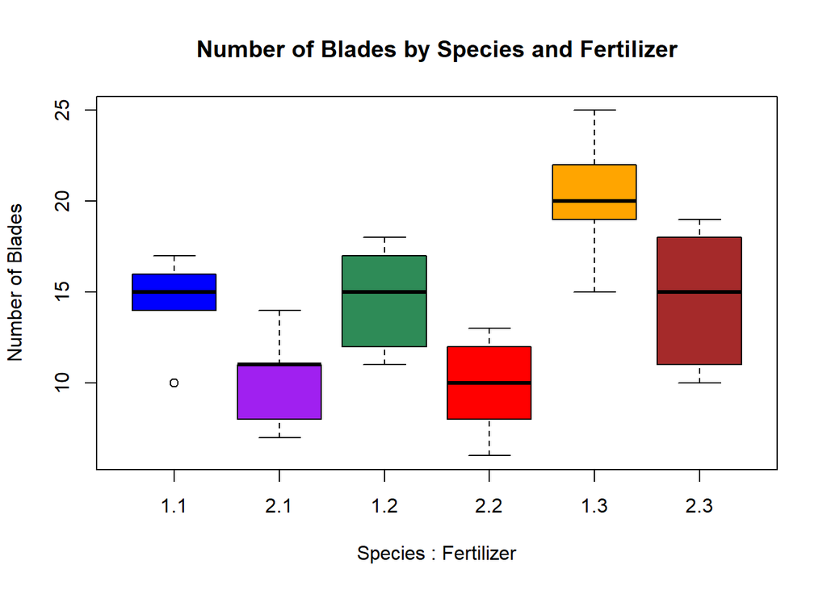

```r
boxplot(Blades ~ Species * Fertilizer, Grass_data, col = c("blue", "purple", "seagreen", "red", "orange", "brown"),
        ylab = "Number of Blades", main = "Number of Blades by Species and Fertilizer")
```

#### Are there any outliers?

For species 1, there is one outlier with approximately 25 blades. Additionally, in the combination of species 1 and fertilizer 1, there is one outlier with around 10 blades.

### A two‐way analysis of variance at the 𝛼= 0.05

```r
# Perform two-way ANOVA
grass_anova <- aov(Blades ~ (Species) * (Fertilizer), data = Grass_data)

# Display the summary
summary(grass_anova)
```

```
##                    Df Sum Sq Mean Sq F value  Pr(>F)
## Species             1 177.63  177.63  17.053 0.00038 ***
## Fertilizer          2 176.87   88.43   8.490 0.00163 **
## Species:Fertilizer  2   2.47    1.23   0.118 0.88886
## Residuals          24 250.00   10.42
## ---
## Signif. codes:  0 '***' 0.001 '**' 0.01 '*' 0.05 '.' 0.1 ' ' 1
```

F_stat and p_value is

Species 17.053 0.00038 respectively

Fertilizer 8.490 0.00163 respectively

Species:Fertilizer 0.118 0.88886 respectively

Species:Fertilizer Interaction: Interpretation : With the p-value (0.88886) greater than 0.05, Therefore, there is no significant interaction effect between species and fertilizer in affecting the number of blades. A higher p-value (greater than 0.05) shows that there isn’t enough evidence to reject the null hypothesis, so i fail to reject the null hypothesis.

Species: Interpretation : with a p_value (0.00038) less than 0.05, Therefore is a significant difference in the mean number of blades between at least two species groups. A small p-value (typically less than the chosen significance level of 0.05) indicates evidence to reject the null hypothesis, so I reject the Null Hypothesis.

Fertilizer: Interpretation : With a P-value (0.00163) less than 0.05,Therefore, is a significant difference in the mean number of blades between at least two fertilizer groups or the three groups. A small p-value (less than 0.05) indicates evidence to reject the null hypothesis, so i reject the null hypothesis.

### The similar variance and normality conditions satisfied? Explain your answers

Independence assumptions: Number of blades of grass in a group will not affect one in another group because they were randomly selected for each grass/fertilizer combination

Randomization assumptions: The data contains randomly group selected for each grass/fertilizer combination.

Independence group assumptions: The question specified they are randomly placed in the group, so one group should not affect the other, so the data are Independent.

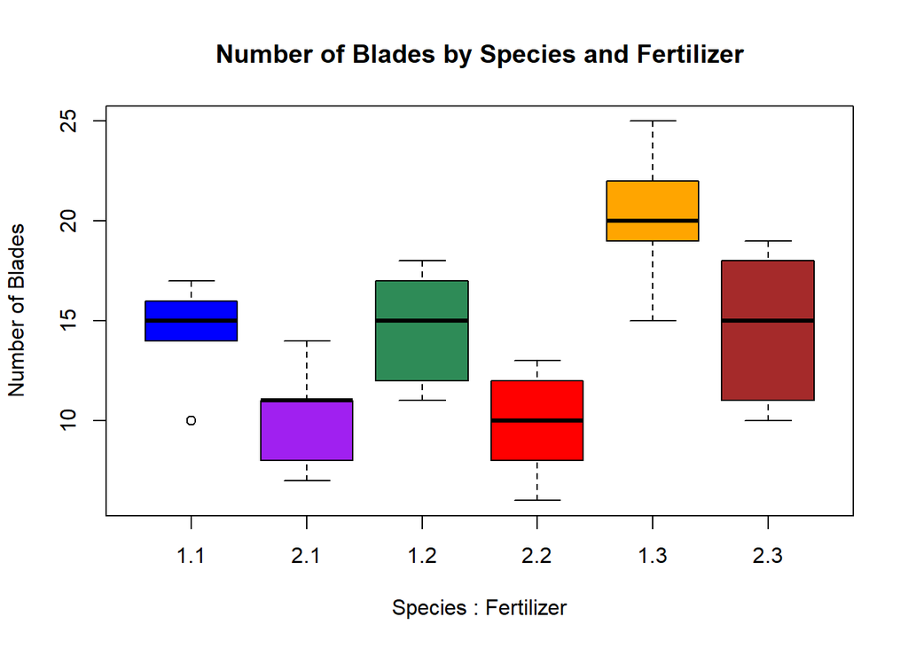

```r
boxplot(Blades ~ Species * Fertilizer, Grass_data, col = c("blue", "purple", "seagreen", "red", "orange", "brown"),
        ylab = "Number of Blades", main = "Number of Blades by Species and Fertilizer")
```

Equal variance:

Group 1.1: Presence of outliers.

Group 2.3: Higher variance compared to the other five groups.

Groups 2.1 and 2.2: Positioned on the lower side of the plot. The highest blade count is below 15.

Group 1.3: Positioned at the highest end of the plot. The lowest blade count is above 15. But I will continue with my analysis.

Normal population assumptions: The histogram is almost unimodel and appears to be evenly distributed. Therefore, the assumptions is met.

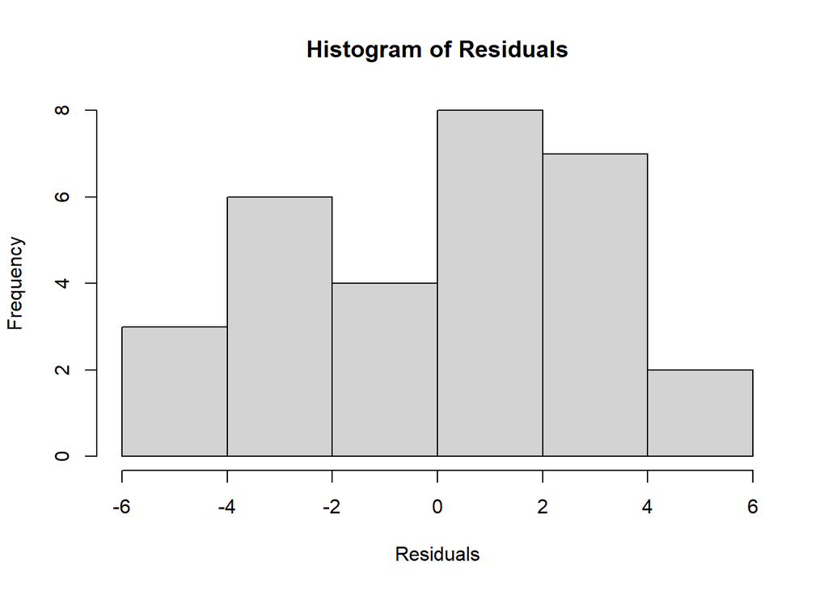

```r
hist(grass_anova$residuals,
     main="Histogram of Residuals",
     xlab="Residuals")
```

### The interaction plot

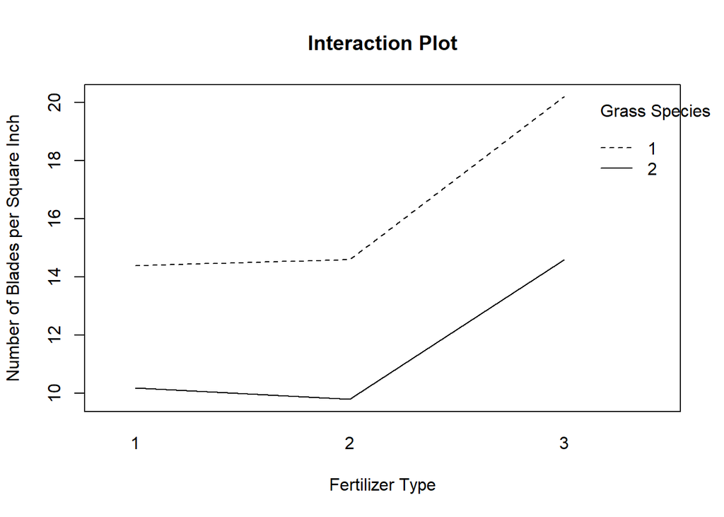

```r
# Interaction Plot
interaction.plot(Grass_data$Fertilizer, Grass_data$Species, Grass_data$Blades,
                 xlab = "Fertilizer Type", ylab = "Number of Blades per Square Inch",
                 main = "Interaction Plot", trace.label = "Grass Species")
```

#### Main effects and interaction

Species: Group 1 has a higher number of blades compared to Group 2.

Fertilizer: Species groups planted with Group 3 fertilizer have higher blades compared to groups using Group 1 and Group 2 fertilizers.

Interaction: Group combination 1.3 (Species: 1, Fertilizer: 3) has more blades than the other five group combinations.

### Tukey’s HSD Test. Interpret any significant values

```r
# Perform Tukey's HSD test
tukey_results <- TukeyHSD(grass_anova, conf.level = 0.95)

# Display the results
print(tukey_results)
```

```
##   Tukey multiple comparisons of means
##     95% family-wise confidence level
##
## Fit: aov(formula = Blades ~ (Species) * (Fertilizer), data = Grass_data)
##
## $Species
##          diff       lwr       upr     p adj
## 2-1 -4.866667 -7.298994 -2.434339 0.0003797
##
## $Fertilizer
##     diff       lwr      upr     p adj
## 2-1 -0.1 -3.704523 3.504523 0.9973574
## 3-1  5.1  1.495477 8.704523 0.0046556
## 3-2  5.2  1.595477 8.804523 0.0039331
##
## $`Species:Fertilizer`
##                  diff         lwr        upr     p adj
## 2:1-1:1 -4.200000e+00 -10.5113778  2.1113778 0.3414959
## 1:2-1:1  2.000000e-01  -6.1113778  6.5113778 0.9999985
## 2:2-1:1 -4.600000e+00 -10.9113778  1.7113778 0.2513588
## 1:3-1:1  5.800000e+00  -0.5113778 12.1113778 0.0845227
## 2:3-1:1  2.000000e-01  -6.1113778  6.5113778 0.9999985
## 1:2-2:1  4.400000e+00  -1.9113778 10.7113778 0.2941863
## 2:2-2:1 -4.000000e-01  -6.7113778  5.9113778 0.9999543
## 1:3-2:1  1.000000e+01   3.6886222 16.3113778 0.0006842
## 2:3-2:1  4.400000e+00  -1.9113778 10.7113778 0.2941863
## 2:2-1:2 -4.800000e+00 -11.1113778  1.5113778 0.2131130
## 1:3-1:2  5.600000e+00  -0.7113778 11.9113778 0.1028989
## 2:3-1:2  3.552714e-15  -6.3113778  6.3113778 1.0000000
## 1:3-2:2  1.040000e+01   4.0886222 16.7113778 0.0004214
## 2:3-2:2  4.800000e+00  -1.5113778 11.1113778 0.2131130
## 2:3-1:3 -5.600000e+00 -11.9113778  0.7113778 0.1028989
```

Significant Differences (p < 0.05):

1:3-2:1: p = 0.0006842 (significant)

1:3-2:2: p = 0.0004214 (significant)

### Bar plots with error bars for both main effects.

```r
library(ggplot2)
```

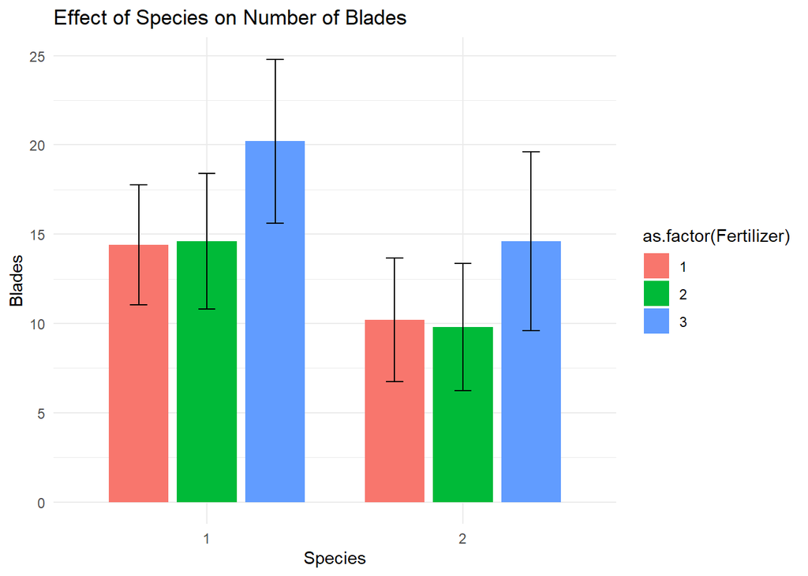

```r
ggplot(Grass_data, aes(x = as.factor(Species), y = Blades, fill = as.factor(Fertilizer))) +
  stat_summary(fun = mean, geom = "bar", position = position_dodge(0.8), width = 0.7) +
  stat_summary(fun.data = mean_cl_normal, geom = "errorbar", position = position_dodge(0.8), width = 0.2) +
  labs(x = "Species", y = "Blades", title = "Effect of Species on Number of Blades") +
  theme_minimal()
```

#### Interpret the results of the plots

From the boxplot above, the combination of Species 1 with Fertilizer 3 consistently exhibited the highest number of blades, falling within the range of 15 to 25. Conversely, the combination of Species 2 with Fertilizer 2 consistently displayed the lowest number of blades, consistently below 15.

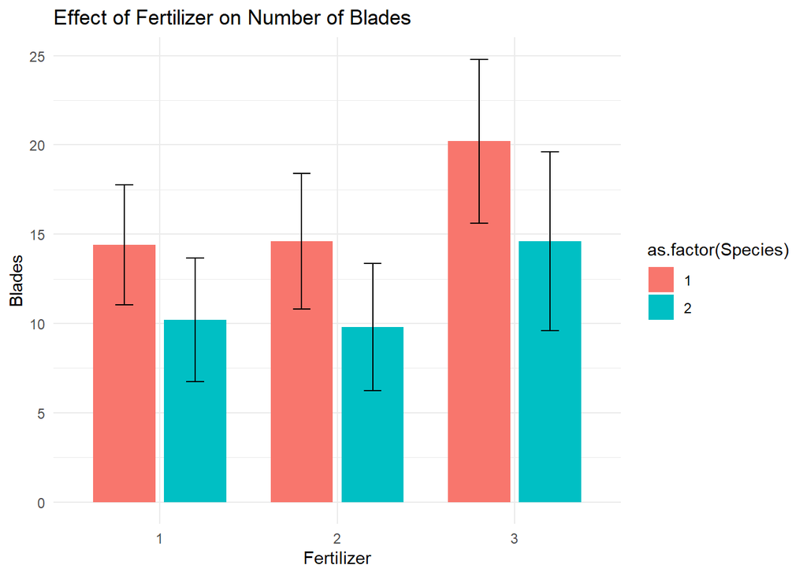

```r
ggplot(Grass_data, aes(x = as.factor(Fertilizer), y = Blades, fill = as.factor(Species))) +
  stat_summary(fun = mean, geom = "bar", position = position_dodge(0.8), width = 0.7) +
  stat_summary(fun.data = mean_cl_normal, geom = "errorbar", position = position_dodge(0.8), width = 0.2) +
  labs(x = "Fertilizer", y = "Blades", title = "Effect of Fertilizer on Number of Blades") +
  theme_minimal()
```

#### Interpret the results of the plots

All instances of Species 1 exhibit a higher number of blades (above 10 blades) compared to Species 2, irrespective of the fertilizer used. Specifically, the combination of Species 1 with Fertilizer 3 demonstrates the highest number of blades among all six combinations.

### Grouped bar plot for species by fertilizer. Use a chosen colour palette

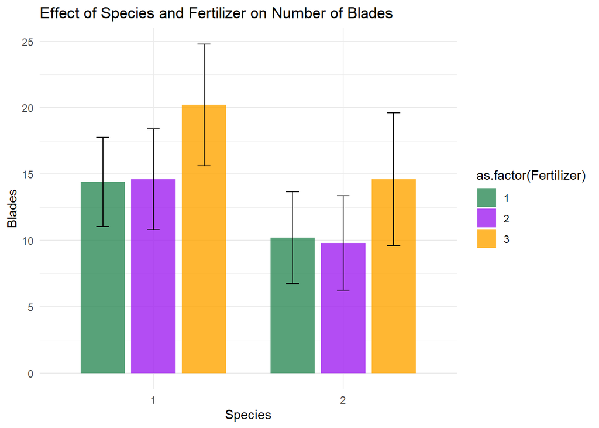

```r
# Choose a color palette
my_palette <- c("seagreen", "purple", "orange")

# Grouped bar plot for Species by Fertilizer
ggplot(Grass_data, aes(x = as.factor(Species), y = Blades, fill = as.factor(Fertilizer))) +
  stat_summary(fun = mean, geom = "bar", position = position_dodge(width = 0.8), width = 0.7, alpha = 0.8) +
  stat_summary(fun.data = mean_cl_normal, geom = "errorbar", position = position_dodge(width = 0.8), width = 0.2) +
  labs(x = "Species", y = "Blades") +
  ggtitle("Effect of Species and Fertilizer on Number of Blades") +
  scale_fill_manual(values = my_palette) +  # Apply the chosen color palette
  theme_minimal()
```